# Desafio 5: Análises Avançados de Tipos de Dados Diversos

O prazo para entregar Desafio 5 por email com título “[FLS6397] - D5” à minha conta é **26/06/2020**. Por favor entregue (i) o arquivo .Rmd (ou .Rnw se preferir), e (ii) o arquivo .html ou .PDF.

# Repostas Sugeridas

## Instruções

Siga as instruções abaixo. Documente *todos* os seus passos em um script. Comente no seu script *todos* os seus passos e explique a si mesma(o) suas escolhas e estratégias. Se você se beneficiou da assistência de outra pessoa, sempre reconheça isso em comentários no código.

## Roteiro

1. Instale e abre [o pacote `geobr` do IBGE](https://github.com/ipeaGIT/geobr). Leia as instruções no site de github do pacote e use a função `read_municipality()` para acessar todos os municípios do estado de São Paulo em 2018.

```r
# install.packages("geobr")
library("tidyverse")
library("sf")
library("geobr")
library("rmarkdown")
library("knitr")

muns_SP <- read_municipality(code_muni="SP", year=2018)
```

2. Use a funcionalidade da família de `map` para aplicar a função `read_municipality` para cinco estados em uma linha única de código: SP, RJ, MT, RS e RN (todos para o ano de 2018).

```r
estados <- c("SP", "RJ", "MT", "RS", "RN")

muns_estados <- estados %>% map(read_municipality, year=2018)
```

3. Visualize um mapa simples usando `ggplot` dos municípios do estado de São Paulo. Formate o seu mapa e adicione um título. (Não precisa mostrar nenhum variável, só as fronteiras dos municípios).

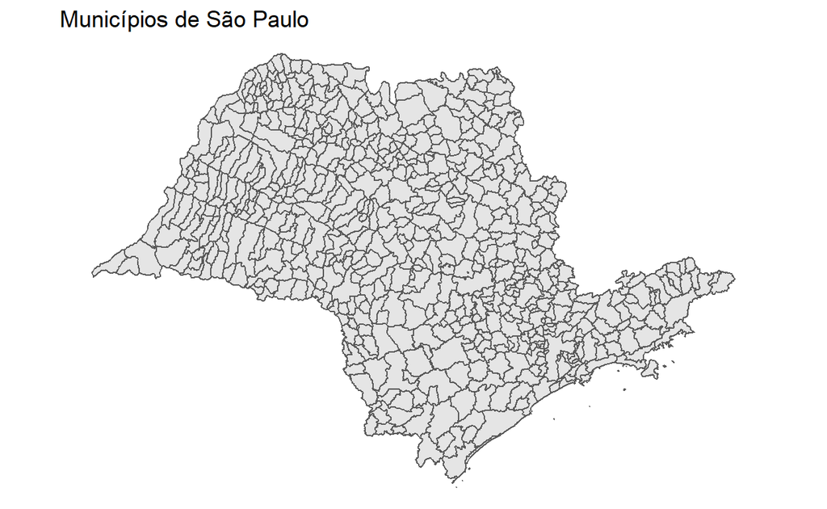

```r
muns_SP %>% ggplot() +
  geom_sf() +
  theme_void() +
  ggtitle("Municípios de São Paulo")
```

4. Baixe, unzip e abre em R o arquivo da população paulista em 2010 [do site do IBGE](https://www.ibge.gov.br/estatisticas/downloads-estatisticas.html), ‘Censos’ -> ‘Censo_Demografico_2010’ -> ‘resultados’ -> ‘total_populacao_sao_paulo.zip’.

```r
library("readxl")

popn_sp <- read_excel("total_populacao_sao_paulo/total_populacao_sao_paulo.xls")

# obs: se não limpar as planilhas, as duas últimas linhas contém dados "errados": o total do estado e o link do site do IBGE de onde a planilha foi tirada
```

5. Queremos mapear dados da população por município. Identifique o chave apropriado, e cruze o banco de população com o banco das fronteiras dos municípios de SP.

```r
popn_sp <- popn_sp %>% mutate(code_muni=as.numeric(`Código do município`))

muns_SP <- muns_SP %>% left_join(popn_sp, by="code_muni")
```

6. Usando o seu banco de dados de Questão 5, calcule a proporção da população urbana na população total em cada município e visualize um mapa bem-formatado dessa taxa por município em 2010. Aplique uma escala de cores desejada.

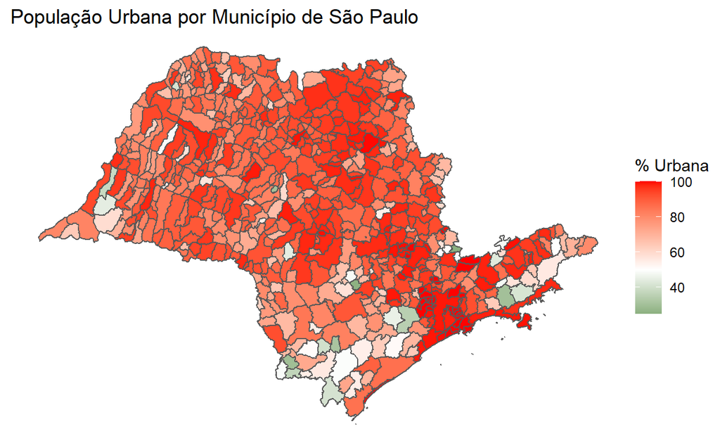

```r
muns_SP <- muns_SP %>% mutate(taxa_urbana=100*(`Total da população urbana`/`Total da população 2010`))

muns_SP %>%
  ggplot() +
  geom_sf(aes(fill=taxa_urbana)) +
  scale_fill_gradient2(name="% Urbana", low="dark green", mid="white", high="red", midpoint=50) +
  theme_void() +
  ggtitle("População Urbana por Município de São Paulo")
```

7. Abre o shapefile no arquivo MCMV_new.zip, que documenta a localização dos projetos de Minha Casa Minha Vida no Brasil, e o número de Unidades Habitacionais (UH) em cada projeto.

```r
MCMV <- st_read("MCMV_new.shp")
```

8. Verifique se a projeção (o CRS) dos dois bancos de dados espaciais (municípios e MCMV) são iguais, e, se necessário, padronize eles para um CRS da sua preferência.

```r
MCMV <- MCMV %>% st_transform(4674)
```

9. Realize um spatial join para informar os dados de MCMV por município do estado de São Paulo, usando a localização dos projetos para juntar com os polígonos dos municípios.

```r
muns_SP_MCMV <- muns_SP %>% st_join(MCMV)
```

10. Visualize um mapa do número de unidades habitacionais (UH) de MCMV por município de São Paulo (por polígono), e adicione uma segunda camada com a localização dos projetos de MCMV (os pontos). Formate o mapa e a escala de cores, e inclua um título.

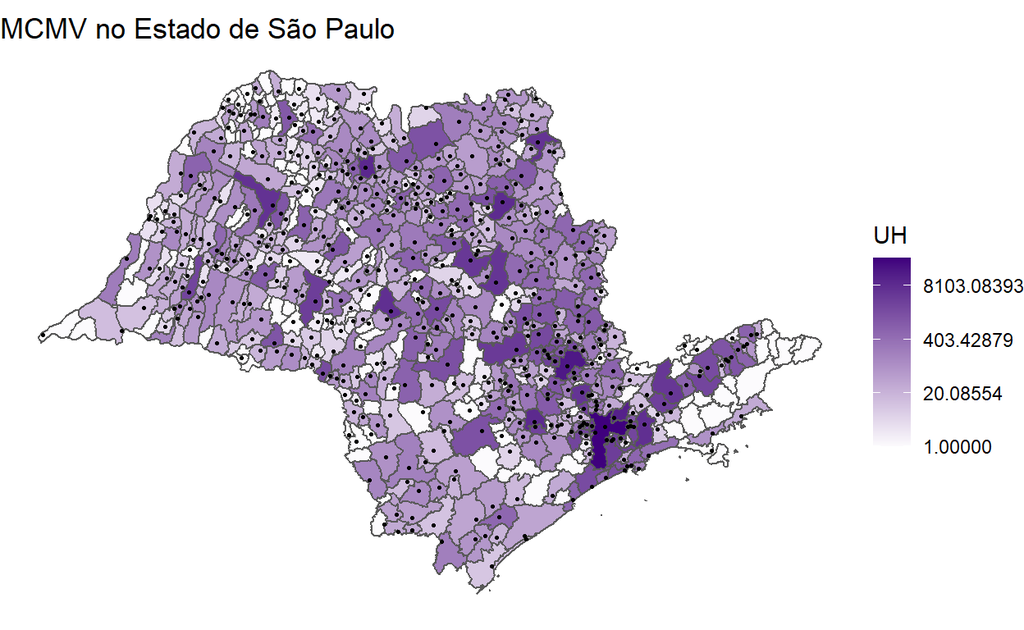

```r
muns_SP_MCMV %>% ggplot() +
  geom_sf(aes(fill=UH)) +
  geom_sf(data=MCMV %>% filter(UF=="SP"), size=0.5) +
  scale_fill_gradient(low="#fcfbfd", high="#3f007d", trans="log", na.value="#fcfbfd") +
  theme_void() +
  ggtitle("MCMV no Estado de São Paulo")
```

11. Imagine que os nossos dados são apenas uma amostra de todos os projetos de MCMV, e o governo de São Paulo se compremeteu a construir exatamente uma média de 600 unidades habitacionais por município. Avalie com a nossa amostra disponível se eles atingiram este objetivo com um t-test da média.

```r
muns_SP_MCMV %>% pull(UH) %>% t.test(mu=600)
```

```
    One Sample t-test

data:  .
t = -0.91397, df = 563, p-value = 0.3611
alternative hypothesis: true mean is not equal to 600
95 percent confidence interval:
 341.4977 694.3250
sample estimates:
mean of x
 517.9113
```

12. Queremos entender por que alguns municípios recebem mais unidades habitacionais (UH) do que outros. Execute uma regressão para avaliar se as seguintes variáveis são correlacionadas com o número de unidades habitacionais (UH): A taxa de população urbana e a população total em 2010. Mande o resultado para uma tabela bem-formatada,

```r
library("stargazer")

muns_SP_MCMV %>% lm(UH ~ taxa_urbana + `Total da população 2010`, data=.)  %>%
  stargazer(type="html", title="Preditores do Número de Unidades Habitacionais de MCMV por Município")
```

**Preditores do Número de Unidades Habitacionais de MCMV por Município**

|  | *Dependent variable:* |
| --- | --- |
|  | UH |
| taxa_urbana | 16.957*** |
|  | (3.520) |
| `Total da população 2010` | 0.004*** |
|  | (0.0001) |
| Constant | -1,204.007*** |
|  | (305.141) |
| Observations | 564 |
| R<sup>2</sup> | 0.737 |
| Adjusted R<sup>2</sup> | 0.736 |
| Residual Std. Error | 1,096.270 (df = 561) |
| F Statistic | 785.167*** (df = 2; 561) |
| *Note:* | p<0.1; p<0.05; p<0.01 |

13. Mostre um gráfico dos efeitos marginais da regressão em Questão 12 - o tamanho dos dois coefficientes e os seus intervalos de confiança.

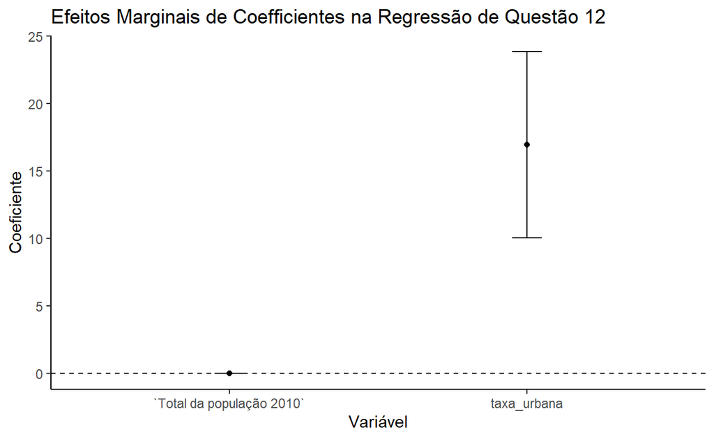

```r
library("broom")
muns_SP_MCMV %>% lm(UH ~ taxa_urbana + `Total da população 2010`, data=.) %>%
  tidy() %>%
  mutate(conf.lo=estimate-1.96*std.error,
         conf.hi=estimate+1.96*std.error) %>%
  filter(term!="(Intercept)") %>%
  ggplot() +
  geom_point(aes(x=term, y=estimate)) +
  geom_errorbar(aes(x=term, y=estimate, ymin=conf.lo, ymax=conf.hi), width=0.1) +
  geom_hline(yintercept=0, lty=2) +
  theme_classic() +
  ggtitle("Efeitos Marginais de Coefficientes na Regressão de Questão 12") +
  xlab("Variável") +
  ylab("Coeficiente")
```

14. Usando o banco de dados nacional de MCMV, use `nest()` para gerar um tibble ‘nested’ por estado. No seu tibble de resumo (com uma linha por estado) use a família de `map` para calcular o número de projetos em cada estado, e o número total de Unidades Habitacionais (UH) em cada estado como novas colunas.

```r
MCMV_nested <- MCMV %>% group_by(UF) %>% nest() %>%
  mutate(Num_Projetos=map_dbl(data, nrow)) %>%
  mutate(Total_UH=map(data, summarize, sum(UH, na.rm=T)),
         Total_UH=map_dbl(Total_UH, 1))
```

```r
MCMV_nested %>% paged_table()
```

| UF | data | Num_Projetos | Total_UH |
| --- | --- | --- | --- |
| AC |  | 10 | 3844 |
| AM |  | 54 | 22348 |
| RO |  | 46 | 10141 |
| RR |  | 6 | 2351 |
| MT |  | 91 | 36043 |
| MS |  | 73 | 28402 |
| PA |  | 99 | 50285 |
| RS |  | 480 | 116779 |
| PR |  | 377 | 106876 |
| SC |  | 282 | 56806 |

[output cut: 17 more lines]

15. O ‘Project_ID’ é um indicador (um proxy) de quando o projeto foi iniciado. Vamos rodar uma regressão para avaliar se projetos mais recentes (com ‘Project_ID’ maior) contém mais Unidades Habitacionais (UH). Use a família `map` e o seu tibble nested de Questão 14 para aplicar *uma regressão por estado*, e guarde os coefficientes e os p-values das regressões em colunas novas do tibble de resumo.

```r
MCMV_nested <- MCMV_nested %>% filter(Num_Projetos>1) %>% mutate(regressao=map(data, ~lm(UH ~ Project_ID, data=.)),
                       regressao=map(regressao, tidy),
                       regressao=map(regressao, filter, term=="Project_ID"),
                       coef=map_dbl(regressao, pull, estimate),
                       p.value=map_dbl(regressao, pull, p.value))
```

```r
MCMV_nested %>% paged_table()
```

| UF | data | Num_Projetos | Total_UH | regressao | coef | p.value |
| --- | --- | --- | --- | --- | --- | --- |
| AC |  | 10 | 3844 |  | 49.41193690 | 3.332300e-01 |
| AM |  | 54 | 22348 |  | 5.53112389 | 4.045511e-01 |
| RO |  | 46 | 10141 |  | -2.99034902 | 5.686240e-01 |
| RR |  | 6 | 2351 |  | -14.82444294 | 8.189072e-01 |
| MT |  | 91 | 36043 |  | -0.52495421 | 3.696994e-01 |
| MS |  | 73 | 28402 |  | -0.31621604 | 7.314262e-01 |
| PA |  | 99 | 50285 |  | -0.04251260 | 8.184174e-01 |
| RS |  | 480 | 116779 |  | 0.32467448 | 3.292163e-03 |
| PR |  | 377 | 106876 |  | 0.42493402 | 1.776093e-03 |
| SC |  | 282 | 56806 |  | 0.25976302 | 7.020835e-04 |

[output cut: 16 more lines]

16. Use [o link aqui](https://escriba.camara.leg.br/escriba-servicosweb/pdf/59638) para acessar em R um PDF da discussão na Camara dos Deputados no dia 21 de Maio de 2020. Transforme o PDF em texto simples.

```r
library("pdftools")

text <- tibble(páginas=pdf_text("https://escriba.camara.leg.br/escriba-servicosweb/pdf/59638"))
```

17. Precisamos processar e preparar o texto para a análise. Segue os seguintes passos:
    1. Insera o texto num tibble
    2. No PDF é possível ver que as falas dos deputados distintos sempre começam com ‘O SR.’ ou ‘A SRA.’ então vamos usar estes strings para dividir o texto por Deputado. Use `str_split` para dividir o texto baseado nos strings ‘O SR.’ ou ‘A SRA.’ e gera uma nova coluna.
    3. Em seguida, `unnest()` os dados para que cada fala de cada deputado é uma linha separado no tibble.
    4. Use `separate` para dividir a fala de cada deputado em duas colunas: O nome do Deputado, e o Discurso, usando o seguinte string como divisor: `"\\) - "`
    5. O resultado deve conter umas linhas em que a coluna ‘Deputado’ não é uma pessoa, mas começa com “Sessão”. Use `filter` para tirar essas linhas que começam com “Sessão” na coluna de ‘Deputado’.
    6. Ainda, o nome do deputado fica desarrumado por causa de conteúdo em parenteses. Para identificar os deputados únicos, use `separate` para dividir a coluna do nome de Deputado em o nome e o conteúdo nos parenteses (que não importa para nos), usando o seguinte string como divisor: `" \\("`.
    7. Tire as colunas desnecessárias para que temos apenas as duas colunas: Nome do Deputado, e Discurso.

```r
text2 <- text %>% mutate(split=str_split(páginas, "O SR.|A SRA.")) %>%
  select(-páginas) %>%
  unnest() %>%
  separate(split, "\\) - ", into=c("Deputado", "Discurso")) %>%
  filter(!(str_detect(Deputado, "^Sessão"))) %>%
  separate(Deputado, " \\(", into=c("Deputado", "Ignorar")) %>%
  select(-Ignorar)
```

18. Agora, com o tibble de Questão 17, vamos desaggregar e padronizar os discursos:
    1. ‘Tokenizar’ os discursos dos deputados em palavras únicas para que o seu tibble contém uma linha por palavra.
    2. Tire os stopwords de português. Se quiser, pode incluir mais stopwords que você acha não relevante para a análise.
    3. Transforme as palavras em suas raízes, os ‘stems’.

```r
library("tidytext")
library("textstem")
library("lexiconPT")

stopwords <- get_stopwords(language="pt") %>%
  rename(palavra=word)

text3 <- text2 %>% unnest_tokens(palavra, Discurso, strip_numeric=TRUE) %>%
  anti_join(stopwords, by="palavra") %>%
  mutate(stem=stem_words(palavra, language="pt"))
```

```r
text2 %>% paged_table()
```

| Deputado | Discurso |
| --- | --- |
| PRESIDENTE | O sistema acusa a participação de 363 Senhoras\r\nDeputadas e Senhores Deputados nesta sessão.\r\nHavendo número regimental, declaro aberta a sessão.\r\nNos termos do art. 7º do Ato da Comissão Direto… |
| PRESIDENTE | Declaro aberta a Ordem do Dia.\r\nConsta na pauta o Projeto de Lei do Congresso Nacional nº 8, de 2020.\r\nPassa-se à deliberação da matéria.\r\nProjeto de Lei (CN) nº 8, de 2020, da Presidência da Re… |
| MARCOS ROGÉRIO | Sr. Presidente, Sras. e Srs.\r\nDeputados, Sras. e Srs. Senadores, considerando o necessário distanciamento social, farei a retirada da máscara para poder\r\nfazer a leitura do meu relatório.\r\nSr. P… |
| PRESIDENTE | Obrigado, Senador Marcos Rogério.\r\nO parecer concluiu pela aprovação do projeto na forma do substitutivo. Ao projeto foram apresentados requerimentos de\r\ndestaques, nos termos do art. 132-A da Res… |
| ENIO VERRI | Sr. Presidente...\r\n 4/32\r\n |
| PRESIDENTE | Pois não, Deputado Enio Verri.\r\n |
| ENIO VERRI | Bom dia, Sr. Presidente!\r\nEu apenas queria pedir a fala como Líder, após a intervenção do Deputado João Daniel, por favor.\r\n |
| PRESIDENTE | Depois do Deputado João Daniel, então V.Exa. terá\r\na palavra.\r\nDeputado João Daniel, V.Exa. tem 5 minutos.\r\n |
| JOÃO DANIEL | Muito obrigado, Sr. Presidente. Obrigado a\r\ntodos. Meus cumprimentos a todos os Parlamentares do Congresso Nacional nesta sessão de hoje.\r\nO nosso partido e a nossa bancada têm sido firmes e forte… |
| PRESIDENTE | Obrigado, Deputado João Daniel.\r\nTem a palavra a Deputada Maria do Rosário. (Pausa.)\r\n |

[output cut: 118 more lines]

19. Gere um ‘wordcloud’ dos stems das palavras usadas pelos Deputados.

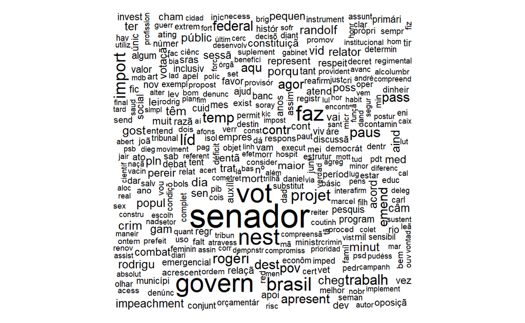

```r
library("wordcloud")
text3 %>% pull(stem) %>% wordcloud()
```

20. Execute uma análise de sentimento para identificar no documento inteiro qual Deputado usa as palavras mais otimistas e qual Deputado usa as palavras mais pessimistas.

```r
data("oplexicon_v3.0") #Abrir o banco de dados de sentimentos

sentimento <- oplexicon_v3.0 %>% select(term, polarity) %>%
  rename(palavra=term)

text3 <- text3 %>% left_join(sentimento, by="palavra")

text3 %>% group_by(Deputado) %>%
  summarize(sentimento=sum(polarity, na.rm=T)) %>%
  arrange(-sentimento) %>%
  slice(1, n()) %>%
  kable()
```

| Deputado | sentimento |
| --- | --- |
| AFONSO MOTTA | 16 |
| PRESIDENTE | -34 |

21. No seu tibble de palavras e Deputados, gere um indicador binário da identidade do Deputado falando - se seja o Presidente da Câmara, ou qualquer outro Deputado (tratando todos juntos). Identifique as cinco palavras mais distintas de cada group (Presidente vs. outros).

```r
text4 <- text3 %>%
  mutate(Presidente=ifelse(Deputado==" PRESIDENTE", 1, 0)) %>%
  group_by(Presidente, palavra) %>%
  tally() %>%
  bind_tf_idf(palavra, Presidente, n)

text4 %>% group_by(Presidente) %>%
  top_n(5, tf_idf) %>%
  kable()
```

| Presidente | palavra | n | tf | idf | tf_idf |
| --- | --- | --- | --- | --- | --- |
| 0 | brasil | 39 | 0.0064516 | 0.6931472 | 0.0044719 |
| 0 | é | 110 | 0.0181969 | 0.6931472 | 0.0126131 |
| 0 | momento | 47 | 0.0077750 | 0.6931472 | 0.0053892 |
| 0 | presidente | 145 | 0.0239868 | 0.6931472 | 0.0166264 |
| 0 | sr | 88 | 0.0145575 | 0.6931472 | 0.0100905 |
| 1 | concedo | 5 | 0.0050000 | 0.6931472 | 0.0034657 |
| 1 | deputada | 17 | 0.0170000 | 0.6931472 | 0.0117835 |
| 1 | dispõe | 5 | 0.0050000 | 0.6931472 | 0.0034657 |
| 1 | minutos | 17 | 0.0170000 | 0.6931472 | 0.0117835 |
| 1 | pausa | 26 | 0.0260000 | 0.6931472 | 0.0180218 |